# CITS4009-project2

Xiao ZHANG

# Part1 - Introduction

## 1.1 - Project Background and Purpose

In this project, our objective is to illustrate the process of modeling by using R machine learning functions. We aim to understand and apply various stages of data science including data preparation, model building, and model evaluation. We have choosen the YouTube dataset which is shared by uni coordinator. We also use the same dataset in our Project 1. The specific contributions of each member will be separated 50-50 fairly.

## 1.2 Data Source and Characteristics

The data set analyzed can be obtained from Kaggle platform. It comes from the “Global YouTube Statistics 2023”. (https://www.kaggle.com/datasets/nelgiriyewithana/global-youtube-statistics-2023)

A collection of YouTube giants, this dataset offers a perfect avenue to analyze and gain valuable insights from the luminaries of the platform. With comprehensive details on top creators’ subscriber counts, video views, upload frequency, country of origin, earnings, and more, this treasure trove of information is a must-explore for aspiring content creators, data enthusiasts, and anyone intrigued by the ever-evolving online content landscape. Immerse yourself in the world of YouTube success and unlock a wealth of knowledge with this extraordinary dataset [1].

# Part2 - Setup

## 2.1 Load required R packages

We load ‘ggplot2’ package [2] for making static graphics and ‘dplyr’ package [3] for data manipulation.

We employ scatterplot matrices and correlation heatmaps for exploratory data analysis to understand the pairwise relationships between variables [4].

We use the skimr package to obtain more comprehensive descriptive statistics of the numeric variables in the dataset [5].

```r
library(ggplot2)
library(gridExtra)
library(dplyr)
library(ggthemes)
library(numform)
library(treemapify)
library(timeDate)
library(lubridate)
library(reshape2)
library(ca)
library(skimr)
library(janitor)
library(flextable)
library(shiny)
library(leaflet)
library(maps)
library(RColorBrewer)
library(scales)
library(readr)
library(forecast)
library(caret)
library(knitr)
library(ROCR)
library(ROCit)
library(nortest)
library(pROC)
library(glmnet)
library(car)
library(nnet)
library(rpart)
library(rpart.plot)
library(pander)
library(e1071)
library(randomForest)
library(fpc)
```

## 2.2 Set plot theme

The theme is set up to enhance the readability and interpretability of the graphs, following the best practices in data visualization [6].

```r
project_theme <- theme(
  panel.background = element_rect(fill = "#FFFBDC"),  # Light yellow background
  panel.grid.major = element_line(color = "#FFE4A1"), # Light orange major grid lines
  panel.grid.minor = element_blank(), # Remove minor grid lines
  plot.title = element_text(size = 18, hjust = 0.5, color = "darkblue"),  # Title color and size
  axis.title = element_text(size = 16, color = "darkblue"),  # Axis title color and size
  axis.text = element_text(size = 14, color = "black"),   # Axis text color and size
  legend.title = element_text(size = 16, color = "darkblue"), # Legend title color and size
  legend.text = element_text(size = 14, color = "black"),   # Legend text color and size
  legend.background = element_rect(fill = "#FFFBDC"),  # Legend background color
  plot.background = element_rect(fill = "#FFFBDC")   # Background color of the entire plot
)
```

## 2.3 Load the main data

In this part, we will load the main dataset, store the path in ‘Data_path’

```r
data_path <- 'Global YouTube Statistics.csv'
raw_data <- read.csv(data_path,encoding = "UTF-8")
```

## 2.4 Dataset initial overview

Before starting in-depth analysis and modeling, it is crucial to perform an initial overview of the dataset. By using functions such as summary, str, etc., we can gain an overall understanding of the data, including data types, data distribution, missing values and possible outliers.

This is the process that we already done in Project 1, according to Professor Wei, we don’t need to do it again so we pass here. So we shorten the content about dataset overview. Mainly is using str; summary;head command to check dataset overview, we also use a function to check dataset skewness. We also shorten or even skip the EDA part in Project 2 report.

we use skimr here, which is similar to summary command but it shows more descriptive statistics for numeric variables than summary command.

```r
skimr::skim(raw_data) |>
  flextable::flextable()
```

Skewness analysis is crucial as it helps in understanding the symmetry of the data distribution [7]. We observe a higher percentage of right-skewed columns in our dataset, which implies that most numerical variables in our dataset have a distribution that has a tail on the right side, meaning the right side of the distribution is longer or fatter than the left side. This can impact the analysis and model performance because many statistical methods assume a normal distribution of the data. Right-skewed distributions are associated with higher values and outliers on the right side of the distribution which can greatly impact the mean and variance, and subsequently, distort the interpretation and performance of the model.

Addressing skewness is often important in regression models where the assumption of normally distributed residuals is made. Therefore, recognizing the presence of skewness can help us make informed decisions about data transformation techniques, such as logarithmic transformation or Box-Cox transformation, to attempt to normalize the data distribution before applying any modeling techniques. For example, this can be particularly relevant for variables like `subscribers`, `uploads`, and `lowest_monthly_earnings`, where skewness might impact the model’s ability to generalize well to unseen data and might lead to unreliable predictions or insights.

Calculate Right skewness numbers and left skewness numbers

```r
calculate_skewness_percentage <- function(dataframe) {
  #initialize function variables
  right_skewed_count <- 0
  left_skewed_count <- 0
  column_names <- names(dataframe)
  #count the numbers with loops
  for (column in column_names) {
    if (is.numeric(dataframe[[column]])) {
      median_value <- median(dataframe[[column]], na.rm = TRUE)
      mean_value <- mean(dataframe[[column]], na.rm = TRUE)
      if (mean_value > median_value) {
        right_skewed_count <- right_skewed_count +1
      } else if (mean_value < median_value) {
        left_skewed_count <- left_skewed_count +1
      }
    }
  }
  #calculate percentage with the count result
  right_percentage <- round((right_skewed_count / ncol(dataframe)) * 100, 2)
  left_percentage <- round((left_skewed_count / ncol(dataframe)) * 100, 2)

  return(list(right_percentage, left_percentage))
}

# Use function to get the calculation result
results <- calculate_skewness_percentage(raw_data)
cat("\n")
```

```r
cat("Percentage of right-skewed columns is:", results[[1]], "%\n")
```

```
## Percentage of right-skewed columns is: 50 %
```

```r
cat("Percentage of left-skewed columns is:", results[[2]], "%\n")
```

```
## Percentage of left-skewed columns is: 21.43 %
```

```r
rm(results)
```

The outcomes of our skewness analysis are telling and significant, revealing that 50% of the columns in our dataset are right-skewed, in contrast to a mere 21.43% being left-skewed. This preponderance of right-skewed columns is pivotal as it unveils a tendency for the distribution of most numerical variables to be tail-heavy on the right side, a characteristic that might have consequential implications for subsequent analyses and modeling efforts.

The presence of such skewed columns underlines the existence of numerous higher values and potential outliers on the right side of the distribution. These extreme values have the capability to significantly inflate the mean and variance of the data, potentially leading to distorted interpretations and undermining the reliability and robustness of our subsequent statistical models.

The substantial right skewness observed in specific variables such as subscribers, uploads, and lowest_monthly_earnings could particularly impact the predictive power and generalizability of the models. Such skewness could render the models less resilient and adaptive to unseen or new data, thereby possibly yielding unreliable predictions or insights.

Employing such transformations could help mitigate the impact of skewness and align the data more closely with the assumptions of many statistical methods, predominantly enhancing the reliability and validity of our subsequent analyses and models.

# Part3 - Data Cleaning and Preparation

## 3.1 Data Cleaning

### 3.1.1 Check column names and make adjustments

First, we use names() command to check each variable name.

```r
names(raw_data)
```

Then, we use janitor package and rename function adjust variable names to ensure uniform formatting.

janitor::clean_names() is a function in the package whose main purpose is to convert the column names of dataframes into a clean, uniform format. Here is the main logic and rules of this function: 1.All characters to lowercase 2.Spaces are converted to underscores 3.Non-alphanumeric characters are removed 4.Numbers before text moved to the end 5.Underline after keyword in R)

```r
raw_data <- janitor::clean_names(raw_data)
```

```r
raw_data <- raw_data %>%
  rename(
    #More descriptive names
    video_views_last_30_days = video_views_for_the_last_30_days,
    country_abbr = abbreviation,
    #Shorter names
    monthly_earnings_low = lowest_monthly_earnings,
    monthly_earning_high = highest_monthly_earnings,
    yearly_earning_low = lowest_yearly_earnings,
    yearly_earning_high = highest_yearly_earnings,
    subs_last_30_days = subscribers_for_last_30_days,
    tertiary_edu_enrollment = gross_tertiary_education_enrollment,
    )
print(colnames(raw_data))
```

```
##  [1] "rank"                     "youtuber"
##  [3] "subscribers"              "video_views"
##  [5] "category"                 "title"
##  [7] "uploads"                  "country"
##  [9] "country_abbr"             "channel_type"
## [11] "video_views_rank"         "country_rank"
## [13] "channel_type_rank"        "video_views_last_30_days"
## [15] "monthly_earnings_low"     "monthly_earning_high"
## [17] "yearly_earning_low"       "yearly_earning_high"
## [19] "subs_last_30_days"        "created_year"
## [21] "created_month"            "created_date"
## [23] "tertiary_edu_enrollment"  "population"
## [25] "unemployment_rate"        "urban_population"
## [27] "latitude"                 "longitude"
```

### 3.1.3 Handle Missing value

We’ve identified three representations for missing data in our dataset: “0”, “NaN”, and “nan”. Our goal is to standardize these by converting them to NA. Following this conversion, we aim to tally the number of NA values in each column. It’s our assumption that “0” serves as a sentinel value indicating missing data.

```r
#Change 0 or 'nan' or 'NaN' to NA value
#Char columns
raw_data[raw_data == 'nan' | raw_data == "NaN" | raw_data == 0] <- NA
#Numeric columns
raw_data <- raw_data |>
  mutate(across(where(is.numeric), ~ifelse(is.nan(.), NA, .)))
```

Use function to calculate how many missing values in each column, handle them.

```r
# Calculate missing value number
count_missing <- function(df) {
  sapply(df, FUN = function(col) sum(is.na(col)) )
}
# Calculate percentage of missing value
percentage_missing <- function(df) {
  sapply(df, FUN = function(col) round(sum(is.na(col)) / length(col) * 100, 2) )
}

nacounts <- count_missing(raw_data)
napercents <- percentage_missing(raw_data)

# output the result
hasNA = which(nacounts > 0)
data.frame(Column = names(nacounts[hasNA]),
           Missing_Values = nacounts[hasNA],
           Percentage_Missing = napercents[hasNA])
```

```
##                                            Column Missing_Values
## video_views                           video_views              8
## category                                 category             46
## uploads                                   uploads             43
## country                                   country            122
## country_abbr                         country_abbr            122
## channel_type                         channel_type             30
## video_views_rank                 video_views_rank              1
## country_rank                         country_rank            116
## channel_type_rank               channel_type_rank             33
## video_views_last_30_days video_views_last_30_days             56
## monthly_earnings_low         monthly_earnings_low            118
## monthly_earning_high         monthly_earning_high             89
## yearly_earning_low             yearly_earning_low             89
## yearly_earning_high           yearly_earning_high             79
## subs_last_30_days               subs_last_30_days            337
## created_year                         created_year              5
## created_month                       created_month              5
## created_date                         created_date              5
## tertiary_edu_enrollment   tertiary_edu_enrollment            123
## population                             population            123
## unemployment_rate               unemployment_rate            123
## urban_population                 urban_population            123
## latitude                                 latitude            123
## longitude                               longitude            123
##                          Percentage_Missing
## video_views                            0.80
## category                               4.62
## uploads                                4.32
## country                               12.26
## country_abbr                          12.26
## channel_type                           3.02
## video_views_rank                       0.10
## country_rank                          11.66
## channel_type_rank                      3.32
## video_views_last_30_days               5.63
## monthly_earnings_low                  11.86
## monthly_earning_high                   8.94
## yearly_earning_low                     8.94
## yearly_earning_high                    7.94
## subs_last_30_days                     33.87
## created_year                           0.50
## created_month                          0.50
## created_date                           0.50
## tertiary_edu_enrollment               12.36
## population                            12.36
## unemployment_rate                     12.36
## urban_population                      12.36
## latitude                              12.36
## longitude                             12.36
```

```r
rm(col,hasNA,nacounts,napercents)
```

Our dataset examination reveals pervasive missing data across multiple columns. Given that our dataset comprises only 995 rows, a sweeping removal of missing values could severely curtail the dataset’s utility for subsequent modeling. In light of this, we’ve devised tailored strategies for addressing different variable types.

Before delving into the strategies for managing missing values, it’s crucial to outline which variables we have decided not to process and provide the rationale behind these choices:

1.Abbreviation: Although it’s feasible to replace its missing entries with ‘Unknown’, a total of 122 missing entries renders it impractical for further processing.

2.Latitude & Longitude: These columns lack intrinsic geographical data. With missing data exceeding 10% of the total, they are deemed not fit for subsequent modeling tasks.

3.Rank, Subscribers, Title & Youtuber: These columns will not be part of our processing pipeline since they manifest no missing values.

Now, let’s delve into the specifics of our chosen strategies for different columns:

1.Video Views: With a scant presence of missing values, we grappled with options between row deletion or median imputation. Given our preference to retain as many rows as possible and the data’s skewed distribution, we’ve opted for median imputation.

3.Earnings: Given its skewed distribution, our chosen strategy leans towards median imputation.

4.Latitude & Longitude: These will be excluded from further analysis due to substantial missing values and an absence of auxiliary geographical information to assist imputation.

5.Time Variables: These aren’t continuous time series, ruling out techniques like ARIMA modeling. Given the paucity of missing data (only 5 rows), which equates to a mere 0.5% of the dataset, we’ve resolved to delete rows with missing time entries, without attempting imputation.

The numeric columns slated for processing are as follows: c(“video_views”, “uploads”, “video_views_rank”, “country_rank”, “channel_type_rank”, “video_views_last_30_days”, “monthly_earnings_low”, “monthly_earning_high”, “yearly_earning_low”, “yearly_earning_high”, “subs_last_30_days”, “tertiary_edu_enrollment”, “population”, “unemployment_rate”, “urban_population”).

The categorical columns in our crosshairs are: c(“category”, “country”, “country_abbr”, “channel_type”).

Our immediate focus will be on the aforementioned numeric columns. Leaning on the outcomes of our skewness analysis, which indicated a predominantly right-skewed data distribution, we’ve favored median imputation over mean imputation. This is predicated on the fact that the median, unlike the mean, won’t perturb the right-skewed nature of the data.

In summary, our overarching strategy centers on the preservation of data integrity, and our chosen imputation methods are reflective of each column’s inherent properties and data distribution.

```r
change_to_median_cols <- c("video_views",
"uploads","video_views_rank","country_rank","channel_type_rank","video_views_last_30_days","monthly_earnings_low",  "monthly_earning_high","yearly_earning_low",     "yearly_earning_high","subs_last_30_days","tertiary_edu_enrollment","population","unemployment_rate","urban_population")
for (col in change_to_median_cols) {
    median_val <- median(raw_data[[col]], na.rm = TRUE)
    raw_data[[col]][is.na(raw_data[[col]])] <- median_val
}
rm(col,median_val,change_to_median_cols)
```

Change the NAs in character variables into “Unknown”

```r
character_columns <- c("category", "country","country_abbr","channel_type")

for (col in character_columns) {
  raw_data[[col]][is.na(raw_data[[col]])] <- "Unknown"
}
rm(col,character_columns)
```

Delete all the missing rows (5 rows) in the time column. Since there are only 5 rows, it does not affect the subsequent analysis. At the same time, delete the rows with the channel creation year less than 2005, because the YouTube company was created in 2005.

```r
raw_data <- raw_data %>%
  filter(!is.na(created_year) & !is.na(created_month) & !is.na(created_date) & created_year >= 2005)
```

Overall, only 6 rows of data were deleted, which does not affect the subsequent analysis because it only accounts for 0.6% of the data.

### 3.1.4 Handle repeating lines

```r
# Use unique function handle repeating lines
raw_data_unique <- unique(raw_data)
raw_data <- raw_data_unique
rm(raw_data_unique)
```

### 3.1.5 Handle outliers

#### 3.1.5.1 classify variables

Change the variables into numerical and categorical according to the data type.

```r
numeric_vars <- raw_data[sapply(raw_data,is.numeric)]
categorical_vars <- raw_data[sapply(raw_data,function(x) class(x) %in% c('factor','character'))]
numeric_vars_name <- names(numeric_vars)
categorical_vars_name <- names(categorical_vars)
```

#### 3.1.5.3 Winsorize outliers

To deal with extreme values in the dataset, we used the method of Winsorizing (shrinking the tails), which sets values greater than the 95th percentile in the dataset to the 95th percentile value. This method has unique advantages over other methods of dealing with outliers, such as truncation or deletion.

First, it preserves much of the original information of the data. Second, truncation reduces the potential adverse effects of extreme values or outliers on the model, thus improving the stability and predictive accuracy of the model.

In addition, some studies have also shown that the results of statistical hypothesis validation and model fit of the model can be effectively improved by appropriate outlier treatment [@Dixon1960].

First,identify which variables are numerical or categorical and set the variables of the category column and the variables of the numeric column

```r
# Function to truncate values in specified columns that exceed a given percentile.
truncate_tail <- function(data, column_names, percentile = 95) {

  # For each column, replace values above the specified percentile with the value at that percentile.
  for (col in column_names) {
    q <- quantile(data[[col]], probs = percentile / 100, na.rm = TRUE)
    data[complete.cases(data) & data[[col]] > q, col] <- q
  }

  return(data)
}

# Apply the function to the first 18 columns of Youtube_cleaned.
raw_data <- truncate_tail(raw_data, numeric_vars_name, percentile = 95)
```

Secondly,summarize how much outliers in each variable

```r
# Function to compute z-scores and detect outliers based on a specified threshold
detect_outliers_zscore <- function(data, column_names, threshold = 3) {
  outliers_count <- sapply(column_names, function(col_name) {
    # Calculate z-scores for each specified column
    z_scores <- (data[[col_name]] - mean(data[[col_name]], na.rm = TRUE)) / sd(data[[col_name]], na.rm = TRUE)
    # Count the number of absolute z-scores that exceed the provided threshold
    sum(abs(z_scores) > threshold, na.rm = TRUE)
  })
  return(outliers_count)
}

# Detect outliers in the data after truncation using the function above
outliers_count_after_truncate <- detect_outliers_zscore(raw_data, numeric_vars_name)
print(outliers_count_after_truncate)
```

```
##                     rank              subscribers              video_views
##                        0                        4                        1
##                  uploads         video_views_rank             country_rank
##                       54                        0                       55
##        channel_type_rank video_views_last_30_days     monthly_earnings_low
##                       53                        2                        2
##     monthly_earning_high       yearly_earning_low      yearly_earning_high
##                        2                        2                        2
##        subs_last_30_days             created_year             created_date
##                        5                        0                        0
##  tertiary_edu_enrollment               population        unemployment_rate
##                        0                        0                        0
##         urban_population                 latitude                longitude
##                        0                       16                        0
```

```r
rm(outliers_count_after_truncate,numeric_vars,categorical_vars)
```

Ultimately, we observe a reduction in the impact of outliers, but it’s impractical to address all of them. Overcorrecting could potentially distort the data. With the cleaning phase now complete, we’re ready to transition to the classification stage.

### 3.1.6 Change data type

Change data type from character to factor for ‘category’, ‘country’, ‘channel type’.

Change some categorical variable to factors to prepare for Classification.

```r
factor_columns <- c("category", "country","country_abbr", "channel_type")
#Use mutate adjust factor_columns, change then to factor type
raw_data <- raw_data %>%
  mutate(across(all_of(factor_columns), as.factor))
rm(factor_columns)
```

### 3.1.7 Backup the processed data

Backup the raw_data into another name youtube_data

```r
youtube_data <- raw_data

clustering_data <- raw_data

clustering_data <- raw_data
```

### 3.1.8 Add new columns

Add new columns which might be used in the future.

#### 3.1.8.1 Full time column

```r
# First, ensure that the 'created_date' column is in integer format
# Assuming the data doesn't contain any decimal parts or NA values
youtube_data$created_date <- as.integer(as.character(raw_data$created_date))

# Check for any non-integer values in 'created_date'
if (any(!is.finite(youtube_data$created_date))) {
  stop("The 'created_date' column contains non-integer or NA values.")
}

# Define a vector of month names
month_names <- c("Jan", "Feb", "Mar", "Apr", "May", "Jun", "Jul", "Aug", "Sep", "Oct", "Nov", "Dec")

# Create a vector of two-digit month numbers using sprintf
month_numbers <- sprintf("%02d", 1:12)

# Create a mapping between month names and month numbers
month_mapping <- setNames(month_numbers, month_names)

# Update the 'full_date' column by combining year, month, and day
youtube_data$full_time <- as.Date(paste(raw_data$created_year,
                                   raw_data$created_month %>% match(month_names) %>% month_mapping[.],
                                   sprintf("%02d", youtube_data$created_date),
                                   sep = "-"),
                             format = "%Y-%m-%d")
rm(month_mapping, month_names, month_numbers)
```

#### 3.1.8.2 Subscriber engagement column

video_views/subscribers. This can give an idea of how many videos, on average, each subscriber watches, offering a measure of engagement for the channel.

```r
youtube_data$subs_engagement <- youtube_data$video_views/youtube_data$subscribers
```

#### 3.1.8.3 Add video upload frequency column

uploads/(2023-created_year). This can show how many videos a YouTuber uploads on average each year since they created their channel.

```r
youtube_data$uploads_frequency <- youtube_data$uploads/(2023-youtube_data$created_year)
```

#### 3.1.8.4 Average views per video column

video_views/uploads. This can help in understanding the average number of views per video, offering a measure of the content’s popularity.

```r
youtube_data$average_views_per_video <- youtube_data$video_views/youtube_data$uploads
```

#### 3.1.8.5 Urbanization rate column

urban_population/population. This will give a percentage of urbanization in a country.

```r
youtube_data$urban_rate <- youtube_data$urban_population/youtube_data$population
```

#### 3.1.8.6 Years of experience column

2022 - created_year. The number of years since the channel was created, which might relate to income and popularity.

```r
youtube_data$age <- 2022-youtube_data$created_year
```

#### 3.1.8.7 Education population ratio column

tertiary_edu_enrollment/population. This gives a ratio of the population that’s undergoing higher education in each country

```r
youtube_data$edu_ratio <- youtube_data$tertiary_edu_enrollment/youtube_data$population
```

#### 3.1.8.8 Top channel flag column

A binary feature based on rank (if channel rank < 1000 then 1, else 0).

```r
youtube_data$top_channel_flag <- as.numeric(youtube_data$channel_type_rank <1000)
```

#### 3.1.8.9 Video views increasing rate column

video_views_last_30_days/ video_view. This shows the increasing rate about video views.

```r
youtube_data$video_views_increasing_rate <- (youtube_data$video_views_last_30_days/youtube_data$video_views)
```

#### 3.1.8.3 Add average earning columns

Average earning for each month and each year.

```r
youtube_data$monthly_earning <-( youtube_data$monthly_earning_high+youtube_data$monthly_earnings_low)/2
youtube_data$yearly_earning <-( youtube_data$yearly_earning_low+youtube_data$yearly_earning_high)/2
```

Observation found that among the overall monthly income and annual income, there are rows where the monthly income is much greater than the annual income. The reason for this problem is that some rows with the lowest monthly income have na values, which turned into average values during previous processing, resulting in this unreasonable situation.

Create a function to identify all these unreasonable rows

```r
detect_unusual_rows <- function(data) {
  unusual_rows <- data[data$monthly_earning > data$yearly_earning, c("monthly_earning", "yearly_earning","monthly_earnings_low","monthly_earning_high","yearly_earning_low","yearly_earning_high")]
  print(unusual_rows)
  cat("The number of unreasonable rows are", nrow(unusual_rows), "rows\n")
}
detect_unusual_rows(youtube_data)
```

```
##     monthly_earning yearly_earning monthly_earnings_low monthly_earning_high
## 2          8900.025          0.310                17800                 0.05
## 15         8900.035          0.455                17800                 0.07
## 17       138975.000      97550.025                17800            260150.00
## 19         8900.030          0.410                17800                 0.06
## 28         8900.020          0.255                17800                 0.04
## 52       138975.000      97550.025                17800            260150.00
## 63         8900.010          0.100                17800                 0.02
## 76         8900.010          0.130                17800                 0.02
## 78         8900.005          0.055                17800                 0.01
## 135      138975.000      97550.025                17800            260150.00
## 173      138975.000      97550.025                17800            260150.00
## 174        8900.030          0.385                17800                 0.06
## 183        8900.005          0.055                17800                 0.01
## 200        8900.030          0.355                17800                 0.06
```

[output cut: 66 more lines]

It can be found that these unreasonable rows account for less than 5% of all rows.To ensure the data integrity of classification,these rows can be deleted. According to the discussion with Sirui Liu in Teams, it is acceptable to delete rows less than 5% in total. For now we delete 45 rows(4.6%).

```r
youtube_data <- youtube_data[youtube_data$monthly_earning <= youtube_data$yearly_earning, ]
```

## 3.2 Data Preparation

### 3.2.1 Object and features

In this project, we would build model and predict the high earning Youtuber on the top list.

For now we pick some features like: “subscribers”,“video_views”,“uploads”,“channel_type”,“created_year”, “subs_engagement”,“uploads_frequency”,“average_views_per_video”,“urban_rate”,“age”,“edu_ratio”,“top_channel_flag”,“video_views_increasing_rate”

Predict variable：high/low earning

All the features and category variables have been prepared in 3.1.8 Section.

Data Integration：

We would use the World Bank GDP data from the Project2 prject description, which includes GDP per capita for each country for each year. Based on the country field merge the GDP for 2022 year. We decided to use 2022 year GDP for each country as a reference. Because our Youtuber data is for 2023, 2022 is the closest year to 2023 in the GDP data, which ensures that real-word economic fluctuations will have the least impact because the years are closest.

Before merge there are some Country.Names that different from the Country.Name in youtube dataset.Change them to the same countries

```r
(diff_countries = setdiff(youtube_data$country, gdp_data$Country.Name))
```

```
## [1] "Unknown"     "Russia"      "South Korea" "Turkey"      "Venezuela"
## [6] "Egypt"
```

```r
gdp_data$Country.Name[gdp_data$Country.Name == "Egypt, Arab Rep."] <- "Egypt"
gdp_data$Country.Name[gdp_data$Country.Name == "Korea, Rep."] <- "South Korea"
gdp_data$Country.Name[gdp_data$Country.Name == "Russian Federation"] <- "Russia"
gdp_data$Country.Name[gdp_data$Country.Name == "Turkiye"] <- "Turkey"
gdp_data$Country.Name[gdp_data$Country.Name == "Venezuela, RB"] <- "Venezuela"
```

```r
replace_na_with_global_median <- function(data) {
  years <- colnames(data)[-1]
  global_median_gdp <- numeric(length(years))

    # change GDP variable into numeric
  for (i in 2:ncol(data)) {
    data[, i] <- as.numeric(data[, i])
  }

  # Calculate global median GDP for each year
  for (i in 1:length(years)) {
    global_median_gdp[i] <- median(data[!is.na(data[, years[i]]), years[i]], na.rm = TRUE)
  }

  data[, years] <- t(apply(data[, years], 1, function(row) {
    is_na <- is.na(row)
    row[is_na] <- global_median_gdp[is_na]
    return(row)
  }))

  return(data)
}


gdp_data <- replace_na_with_global_median(gdp_data)
```

Calculate GDP value based on Youtube channel age

```r
# Divide the per capital GDP value in those years of channel age by the channel age in these years
calculate_channel_age_adjusted_income <- function(youtube_data, gdp_data) {

  adjusted_income <- numeric(nrow(youtube_data))

  # Iterate through each row of youtube_data
  for (i in 1:nrow(youtube_data)) {

    country <- as.character(youtube_data$country[i])
    created_year <- as.numeric(as.character(youtube_data$created_year[i]))

    # Find the corresponding country row in gdp_data
    gdp_row <- gdp_data[gdp_data$`Country.Name` == country, ]
    created_year_column <- which(names(gdp_row) == created_year)

    if (nrow(gdp_row) == 0) {
      adjusted_income[i] <- NA
    } else {
      gdp_values <- as.numeric(gdp_row[ , (created_year_column + 1):64])

      value1 <- sum(gdp_values, na.rm = TRUE)

      value2 <- 1 / youtube_data$age[i]

      adjusted_income[i] <- youtube_data$yearly_earning[i] / value2
    }
  }

  youtube_data$channel_age_adjusted_income <- adjusted_income

  return(youtube_data)
}


youtube_data <- calculate_channel_age_adjusted_income(youtube_data, gdp_data)
```

Handle NAs in the channel_age_adjusted_income column

```r
median_value <- median(youtube_data$channel_age_adjusted_income, na.rm = TRUE)


for (i in 1:length(youtube_data$channel_age_adjusted_income)) {
  if (is.na(youtube_data$channel_age_adjusted_income[i])) {
    youtube_data$channel_age_adjusted_income[i] <- median_value
  }
}
```

Use merge command here.

```r
gdp_2022 <- gdp_data[,c("Country.Name","gdp_per_capita")]

youtube_data <- merge(youtube_data,gdp_2022, by.x = "country",by.y = "Country.Name", all.x = TRUE)
rm(gdp_2022)
```

If the Country.Name is “Unknown”, then we would use the medium of youtube_data$gdp_per_capita to swap it, it won’t affect our data too much, and also, this is the same handling method that we used before in 3.1.3 Handle Missing value. Consistency is ensured here.

```r
median_gdp <- median(youtube_data$gdp_per_capita,na.rm = TRUE)
youtube_data$gdp_per_capita[is.na(youtube_data$gdp_per_capita)] <- median_gdp
rm(median_gdp)
```

Normalize Youtuber earning：

We start by using Youtuber yearly earning divided by GDP per capita to observe how many time the Youtuber’s income is the country’s per capita income. Here we use annual income divided by GPD per capita, the reason for using average annual income rather than average monthly income is that anuual income is more stable and reduces fluctuations in income due to seasonality or other short term factors. Secondly, annual income is more objective when compared to annual GDP per capita.

```r
youtube_data$normalized_earning <- as.numeric(youtube_data$yearly_earning/youtube_data$gdp_per_capita)
```

Logic for defining high income:

We would like to use the mean and add a certain number of standard deviations as a threshold for high income based on the standard deviation, but with this approach we have to first assume that income is normally distributed, which is not always the case in reality.

Validation Definition:

We want to verify that our data is normally distributed by visualizing a graph.

```r
summary(youtube_data$normalized_earning)
```

```
##    Min. 1st Qu.  Median    Mean 3rd Qu.    Max.
##    0.00   19.47   62.30  489.62  311.13 9438.44
```

As we can see there is a huge gap between the median and the mean. So we continue with kernel density estimates, and statistical tests, here we used the Shapiro-Wilk test; the Kolmogorov-Smirnov test; and the Anderson-Darling test

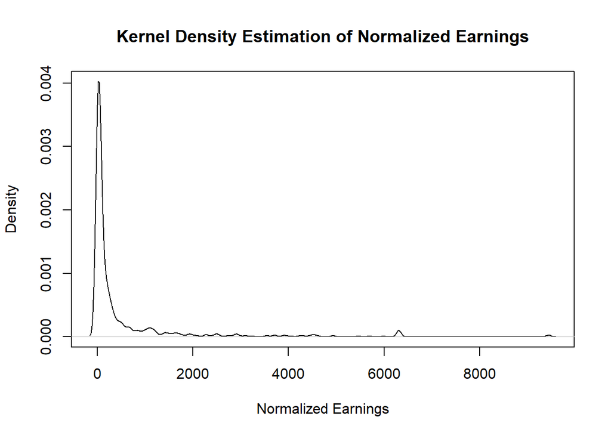

```r
#Kernel Density Estimation
plot(density(youtube_data$normalized_earning), main="Kernel Density Estimation of Normalized Earnings", xlab="Normalized Earnings")
```

```r
# Shapiro-Wilk test
shapiro_test <- shapiro.test(youtube_data$normalized_earning)
print(shapiro_test)
```

```
##
##  Shapiro-Wilk normality test
##
## data:  youtube_data$normalized_earning
## W = 0.45036, p-value < 2.2e-16
```

```r
# Kolmogorov-Smirnov test
ks_test <- ks.test(youtube_data$normalized_earning, "pnorm", mean(youtube_data$normalized_earning), sd(youtube_data$normalized_earning))
print(ks_test)
```

```
##
##  Asymptotic one-sample Kolmogorov-Smirnov test
##
## data:  youtube_data$normalized_earning
## D = 0.33833, p-value < 2.2e-16
## alternative hypothesis: two-sided
```

```r
# Anderson-Darling test
ad_test <- ad.test(youtube_data$normalized_earning)
print(ad_test)
```

```
##
##  Anderson-Darling normality test
##
## data:  youtube_data$normalized_earning
## A = 188.25, p-value < 2.2e-16
```

Shapiro-Wilk normality test.

Anderson-Darling normality test.

Summary: All three tests consistently show that the youtube_data$normalized_earning data does not currently conform to a normal distribution.

Adjustment and Optimization:

While modern machine learning algorithms do not require the data to meet the assumption of a normal distribution. However, bringing the data closer to a normal distribution can improve model performance, especially for models such as linear regression and logistic regression.

We observe some very large values from the density plot, they are much larger than thousands of times the average GDP, and for these values they are simply too different. We will use a logarithmic transformation.The results of data analysis show that after Log-transformation, the data presents different distribution characteristics[9]. More conducive to classification, which is what we learned from class to reduce the effect of these too large values. After that the multiples were adjusted to between 0-10, and according to the Density image, it’s also leaning more towards a normal distribution.

```r
youtube_data$normalized_earning <- log(youtube_data$normalized_earning + 1)
```

```r
summary(youtube_data$normalized_earning)
```

```
##     Min.  1st Qu.   Median     Mean  3rd Qu.     Max.
## 0.000007 3.018837 4.147872 4.312888 5.743422 9.152652
```

```r
# Shapiro-Wilk test
shapiro_test <- shapiro.test(youtube_data$normalized_earning)
print(shapiro_test)
```

```
##
##  Shapiro-Wilk normality test
##
## data:  youtube_data$normalized_earning
## W = 0.98539, p-value = 3.893e-08
```

```r
# Kolmogorov-Smirnov test
ks_test <- ks.test(youtube_data$normalized_earning, "pnorm", mean(youtube_data$normalized_earning), sd(youtube_data$normalized_earning))
print(ks_test)
```

```
##
##  Asymptotic one-sample Kolmogorov-Smirnov test
##
## data:  youtube_data$normalized_earning
## D = 0.035595, p-value = 0.18
## alternative hypothesis: two-sided
```

```r
# Anderson-Darling test
ad_test <- ad.test(youtube_data$normalized_earning)
print(ad_test)
```

```
##
##  Anderson-Darling normality test
##
## data:  youtube_data$normalized_earning
## A = 2.0513, p-value = 3.205e-05
```

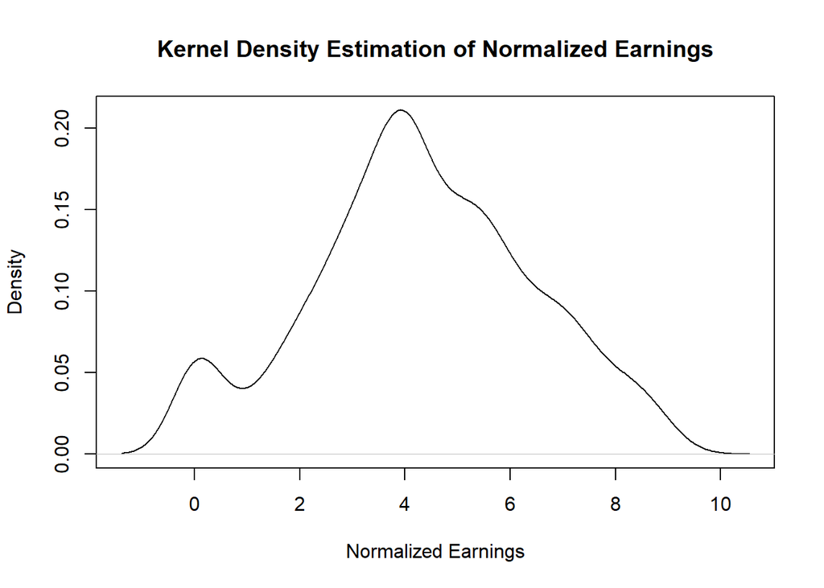

```r
# Density plot
plot(density(youtube_data$normalized_earning), main="Kernel Density Estimation of Normalized Earnings", xlab="Normalized Earnings")
```

```r
rm(ad_test,ks_test,shapiro_test)
```

Shapiro-Wilk Test.

youtube_data$normalized_earning is close to a normal distribution, although it is not exactly normal. Many real-world applications have data that do not strictly follow a normal distribution, but if they are close enough, many of the properties of a normal distribution are still useful.

```r
earning_threshold <- median(youtube_data$normalized_earning)+sd(youtube_data$normalized_earning)
print(earning_threshold)
```

```
## [1] 6.264244
```

### 3.2.2 Tranform categrical variables

Because the first time we built the decision tree model, the model had too many nodes, resulting in overfitting. This is the second time to re-establish the model, so we need to modify the categorical variables and change the categorical variables into factors with fewer levels. This may enhance the generalization ability of the model.

First, Check the number of occurrences of each country

```r
print(table(youtube_data$country))
```

```
##
##          Afghanistan              Andorra            Argentina
##                    1                    1                   12
##            Australia           Bangladesh             Barbados
##                    8                    0                    1
##               Brazil               Canada                Chile
##                   61                   15                    3
##                China             Colombia                 Cuba
##                    1                   11                    1
##              Ecuador                Egypt          El Salvador
##                    2                    2                    1
##              Finland               France              Germany
##                    1                    5                    6
##                India            Indonesia                 Iraq
##                  165                   28                    2
##                Italy                Japan               Jordan
##                    2                    5                    3
##               Kuwait               Latvia             Malaysia
##                    1                    1                    1
##               Mexico              Morocco          Netherlands
##                   33                    1                    3
##             Pakistan                 Peru          Philippines
##                    6                    1                   12
##               Russia                Samoa         Saudi Arabia
##                   16                    1                    9
##            Singapore          South Korea                Spain
##                    3                   17                   21
##               Sweden          Switzerland             Thailand
##                    4                    1                   18
##               Turkey              Ukraine United Arab Emirates
##                    4                    8                    7
##       United Kingdom        United States              Unknown
##                   42                  307                   92
##            Venezuela              Vietnam
##                    1                    3
```

Turn country variables into factors and then divide them into developed countries, developing countries, and unknown levels.

```r
youtube_data$country_status <- factor(ifelse(youtube_data$country %in% c("Japan","Germany","Canada","United States", "United Kingdom","Denmark", "Australia","China","South Korea", "Switzerland", "Sweden", "Finland", "France", "Norway", "Singapore", "Netherlands", "Italy", "Brazil", "Belgium", "Greece", "Iceland", "Luxembourg", "Spain"), "Developed", ifelse(youtube_data$country == "Unknown", "Unknown", "Developing")))
```

Second, There are too many levels of channel types, which may also lead to overfitting, so the channel occurrence number is less than or equal to 20 and unknown are classified into the others category.

```r
print(table(youtube_data$channel_type))
```

```
##
##       Animals         Autos        Comedy     Education Entertainment
##             3             3            50            48           297
##          Film         Games         Howto         Music          News
##            41            95            36           208            30
##     Nonprofit        People        Sports          Tech       Unknown
##             2            87            11            16            23
```

```r
print(table(youtube_data$channel_type) < 20)
```

```
##
##       Animals         Autos        Comedy     Education Entertainment
##          TRUE          TRUE         FALSE         FALSE         FALSE
##          Film         Games         Howto         Music          News
##         FALSE         FALSE         FALSE         FALSE         FALSE
##     Nonprofit        People        Sports          Tech       Unknown
##          TRUE         FALSE          TRUE          TRUE         FALSE
```

```r
youtube_data$channel_type_status <- factor(ifelse(youtube_data$channel_type %in% c("Animals","Autos","Nonprofit","Sports","Tech","Unknown"),"Others",as.character(youtube_data$channel_type)))
```

### 3.2.3 Remove unrelevant columns

According to the instructions of project 2. Columns that have a unique value for each row should be discarded, e.g., rank, Youtuber, etc.List all the columns that have a unique values for each row and then delete those columns.

```r
youtube_data <- youtube_data[
  c(
    "normalized_earning",
    "subscribers","video_views","uploads","channel_type_status","created_year","category",
    "subs_engagement","uploads_frequency","average_views_per_video","urban_rate","age","edu_ratio","top_channel_flag","video_views_increasing_rate","channel_age_adjusted_income","country_status"
    )
  ]
```

### 3.2.4 Feature Engineering

We have already created required features in 3.1.8 Section.

“subs_engagement”,“uploads_frequency”,“average_views_per_video”,“urban_rate”,“age”,“edu_ratio”,“top_channel_flag”,“video_views_increasing_rate”

```r
youtube_data$earning_class <- ifelse(youtube_data$normalized_earning > 6.2, 1, 0)
youtube_data <- subset(youtube_data, select = -normalized_earning)
```

```r
names(youtube_data)
```

```
##  [1] "subscribers"                 "video_views"
##  [3] "uploads"                     "channel_type_status"
##  [5] "created_year"                "category"
##  [7] "subs_engagement"             "uploads_frequency"
##  [9] "average_views_per_video"     "urban_rate"
## [11] "age"                         "edu_ratio"
## [13] "top_channel_flag"            "video_views_increasing_rate"
## [15] "channel_age_adjusted_income" "country_status"
## [17] "earning_class"
```

### 3.2.5 Training and Testing dataset

After google many articles and learn caret pacakge by ourselves, we decide to use “creatDataPartition” function in caret package, it ensures that the distribution of the target variable is taken into account when partitioning the data.[8]

```r
# Set a seed for reproducibility
set.seed(562816)

train_index <- createDataPartition(youtube_data$earning_class, p = 0.8, list = FALSE, times = 1)

# Subset the original dataset to create training and testing datasets based on the indices generated above.
youtube_train <- youtube_data[train_index, ]
youtube_test  <- youtube_data[-train_index, ]

# Identify and store the names of all independent variables (i.e., all variables excluding the target 'earning_class').
independent_variables <- setdiff(colnames(youtube_data), "earning_class")

# From the list of independent variables, identify and store the names of numeric and integer type variables.
numeric_independent_variables <- independent_variables[sapply(youtube_data[, independent_variables], class) %in% c("numeric", "integer")]

# Similarly, from the list of independent variables, identify and store the names of factor and character type variables.
categorical_independent_variables <- independent_variables[sapply(youtube_data[, independent_variables], class) %in% c("factor", "character")]
```

# Part4 Classification

## 4.1 Dependent Variable & Independent Variable

Dependent Variable: earning_class

## 4.2 Single Variable Classification

### 4.2.1 Function build up

Build single variable model function. Use Single variable model for each variable to determine which has the most predictive power.

```r
#Define target column and positive label
target_column <- 'earning_class'
positive_label <- '1'
```

```r
Single_variable_model <- function(target_column, feature_column, prediction_column){

  # Ensure that the input vectors are of the same length
  if (!(length(target_column) == length(feature_column) && length(target_column) == length(prediction_column))) {
    stop("All input vectors must have the same length")
  }

  # Small constant to avoid division by zero
  epsilon <- 1.0e-3

  # Calculate the overall probability of the positive class
  probility_of_positive <- sum(target_column == positive_label) / length(target_column)

  # For NAs in feature_column, compute the distribution of target_column
  na_table <- table(as.factor(target_column[is.na(feature_column)]))

  # For NAs in feature_column, compute the conditional probability of the positive class
  probility_of_positive_with_na <- ifelse(is.na((na_table / sum(na_table))[positive_label]), probility_of_positive, (na_table / sum(na_table))[positive_label])

  # Create a table to represent the relationship between different values of feature_column and target_column
  value_table <- table(as.factor(target_column), feature_column, useNA = "ifany")

  # Compute conditional probabilities for each value of feature_column
  probility_of_positive_with_val <- (value_table[positive_label, ] + epsilon * probility_of_positive) / (colSums(value_table) + epsilon)

  # Generate predictions based on conditional probabilities
  predictions <- probility_of_positive_with_val[prediction_column]

  # Handle NA values in prediction_column
  predictions[is.na(prediction_column)] <- probility_of_positive_with_na

  # Handle values in prediction_column that didn't appear in the training data
  predictions[is.na(predictions)] <- probility_of_positive

  # Return predictions
  return(predictions)
}
```

Build up AUC calculator function.

```r
AUC_calculator <- function(predcol, outcol) {
    perf <- performance(prediction(predcol, outcol == positive_label), 'auc')
    return(as.numeric(perf@y.values))
}
```

```r
# Create a function to discretize numeric columns
discretizeVariable <- function(column) {
    quantiles <- quantile(column, probs = seq(0, 1, 0.1), na.rm = TRUE)
    discrete_column <- cut(column, unique(quantiles))
    return(discrete_column)
}
```

```r
# single variable prediction function
SingleVariablePredictNumeric <- function(target_column, feature_column, prediction_column, subset) {
    feature_discrete <- discretizeVariable(feature_column[subset])
    prediction_discrete <- discretizeVariable(prediction_column[subset])
    return(Single_variable_model(target_column[subset], feature_discrete, prediction_discrete))
}
```

### 4.2.2 Analyze Variables

#### 4.2.2.1 Analyzing Categorical variables:

Call Single variable model & AUC calculator function, check AUC value for categorical independent variables.

```r
for (var in categorical_independent_variables) {
    prediction_probs <- Single_variable_model(target_column = youtube_train$earning_class,
                                             feature_column = youtube_train[, var],
                                             prediction_column = youtube_train[, var])
    auc <- AUC_calculator(prediction_probs, youtube_train$earning_class)
    if (auc >= 0.1) {
        print(sprintf("%s - AUC: %4.3f", var, auc))
    }
}
```

```
## [1] "channel_type_status - AUC: 0.666"
## [1] "category - AUC: 0.691"
## [1] "country_status - AUC: 0.852"
```

#### 4.2.2.2 Analyzing Numeric variables:

Check the AUC value for numeric independent variables. We need to change the numeric data into category data first as the instruction in Week9 Slides.

```r
for (var in numeric_independent_variables) {
    pred_col_name <- paste('pred', var, sep = '_')
    youtube_train[, pred_col_name] <- SingleVariablePredictNumeric(youtube_train$earning_class, youtube_train[, var], youtube_train[, var])
    auc_train <- AUC_calculator(youtube_train[, pred_col_name], youtube_train$earning_class)
    if (auc_train >= 0.55) {
        print(sprintf("%s: AUC: %4.3f", var, auc_train))
    }
}
```

```
## [1] "subscribers: AUC: 0.649"
## [1] "video_views: AUC: 0.697"
## [1] "uploads: AUC: 0.711"
## [1] "created_year: AUC: 0.586"
## [1] "subs_engagement: AUC: 0.692"
## [1] "uploads_frequency: AUC: 0.749"
## [1] "average_views_per_video: AUC: 0.651"
## [1] "urban_rate: AUC: 0.899"
## [1] "age: AUC: 0.571"
## [1] "edu_ratio: AUC: 0.885"
## [1] "top_channel_flag: AUC: 0.552"
## [1] "video_views_increasing_rate: AUC: 0.788"
## [1] "channel_age_adjusted_income: AUC: 0.807"
```

Using 100-fold cross-validation

```r
vars <- numeric_independent_variables

for (var in vars) {
    aucs <- rep(0, 100)

    for (rep in 1:length(aucs)) {
        useForCalRep <- rbinom(n=nrow(youtube_train), size=1, prob=0.1) > 0

        predRep <- SingleVariablePredictNumeric(youtube_train$earning_class,
                                                youtube_train[, var],
                                                youtube_train[, var],
                                                !useForCalRep)  # Pass the subset to the function

        # Only calculate AUC for the subset used for prediction
        actual_subset_labels = youtube_train$earning_class[!useForCalRep]
        aucs[rep] <- AUC_calculator(predRep, actual_subset_labels)
    }

    print(sprintf("%s: mean: %4.3f; sd: %4.3f", var, mean(aucs), sd(aucs)))
}
```

```
## [1] "subscribers: mean: 0.648; sd: 0.009"
## [1] "video_views: mean: 0.701; sd: 0.009"
## [1] "uploads: mean: 0.714; sd: 0.008"
## [1] "created_year: mean: 0.589; sd: 0.009"
## [1] "subs_engagement: mean: 0.693; sd: 0.009"
## [1] "uploads_frequency: mean: 0.745; sd: 0.008"
## [1] "average_views_per_video: mean: 0.659; sd: 0.008"
## [1] "urban_rate: mean: 0.900; sd: 0.007"
## [1] "age: mean: 0.576; sd: 0.010"
## [1] "edu_ratio: mean: 0.884; sd: 0.007"
## [1] "top_channel_flag: mean: 0.552; sd: 0.002"
## [1] "video_views_increasing_rate: mean: 0.791; sd: 0.008"
## [1] "channel_age_adjusted_income: mean: 0.811; sd: 0.006"
```

Urban_rate (0.899) and edu_ratio (0.884) are still the best performing predictive features. These two features perform very well in predicting the target variable.

The features video_views_increasing_rate (0.790) and channel_age_adjusted_income (0.810) are still better features with strong predictive power.

The AUC values of the two features video_views (0.700), subs_engagement (0.692) and average_views_per_video (0.659) are still relatively high, showing moderate predictive power.

The AUC value of feature uploads (0.714) increased slightly, but is still within the previously mentioned range.

The feature top_channel_flag (0.552) has the lowest AUC value, which indicates that it may contribute less to predicting the target variable.

### 4.2.3 ROC plot

ROC plots are displayed in the last part of shiny

```r
library(ROCit)

plot_roc <- function(predcol, outcol, colour_id=2, overlaid=FALSE) {
    ROCit_obj <- rocit(score = predcol, class = outcol == positive_label)
    par(new = overlaid)
    plot(ROCit_obj, col = c(colour_id, 1), legend = FALSE, YIndex = FALSE, values = FALSE)
}
```

double density comparing AUC

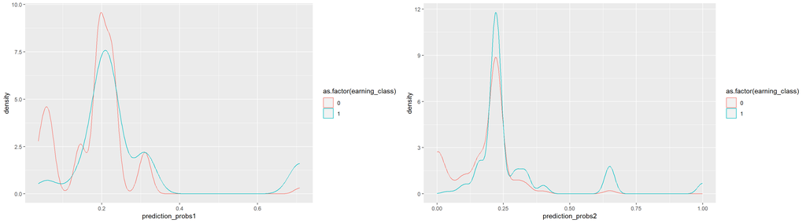

```r
# Compare the AUC of the first two categorical variables
var1 <- categorical_independent_variables[1]
var2 <- categorical_independent_variables[2]

prediction_probs1 <- Single_variable_model(target_column = youtube_train$earning_class,
                                          feature_column = youtube_train[, var1],
                                          prediction_column = youtube_train[, var1])

prediction_probs2 <- Single_variable_model(target_column = youtube_train$earning_class,
                                          feature_column = youtube_train[, var2],
                                          prediction_column = youtube_train[, var2])

fig1 <- ggplot(youtube_train) + geom_density(aes(x = prediction_probs1, color = as.factor(earning_class)))
fig2 <- ggplot(youtube_train) + geom_density(aes(x = prediction_probs2, color = as.factor(earning_class)))

grid.arrange(fig1, fig2, ncol=2)
```

## 4.3 Null model

### 4.3.1 Build Null Model

According to the knowledge of lectures, If the AUC value of a single variable model is close to or lower than the AUC value of the null model, it means that the single variable model may not provide enough information for predicting the target variable. In this case, using this single variable model may not have a significant impact on model performance.By analyzing only the target variable, a null model is created and the AUC of the model is evaluated. The AUC value of the null model can help comparing single variable.

```r
# Calculate the number of positive class instances (Npos)
Npos <- sum(youtube_train[, target_column] == 1)
cat("Number of positive class (target_column == 1) in youtube_train:", Npos, "rows\n")
```

```
## Number of positive class (target_column == 1) in youtube_train: 152 rows
```

```r
# Calculate the number of negative class instances (Nneg)
Nneg <- nrow(youtube_train) - Npos
cat("Number of negative class (target_column == 0) in youtube_train:", Nneg, "rows\n")
```

```
## Number of negative class (target_column == 0) in youtube_train: 608 rows
```

```r
# Calculate the Null Model prediction, which is the proportion of positive class
pred.Null <- Npos / (Npos + Nneg)
cat("Proportion of target_column == 1 in youtube_train (Null Model prediction):", pred.Null, "\n")
```

```
## Proportion of target_column == 1 in youtube_train (Null Model prediction): 0.2
```

```r
# Create a vector of Null Model predictions with the same length as the dataset
null_model_predictions <- rep(pred.Null, nrow(youtube_train))

# Calculate the Null Model AUC using the pROC package
library(pROC)
roc_obj <- roc(youtube_train[, target_column], null_model_predictions)
null_model_auc <- auc(roc_obj)

cat("Null Model AUC:", null_model_auc, "\n")
```

```
## Null Model AUC: 0.5
```

## 4.4 Feature Selection

We will use different methods to divide features into different combinations for modeling. The most basic combination is all features

```r
feature_combine1 <- c(categorical_independent_variables,numeric_independent_variables)
```

### 4.4.1 Likelihood and deviance

First calculate the log likelihood of the null model as the standard

```r
positive_label <- '1'
# Define a function to compute log likelihood
logLikelihood <- function(ytrue, ypred, epsilon=1e-6) {
                          sum(ifelse(ytrue==positive_label, log(ypred+epsilon), log(1-ypred-epsilon)), na.rm=T)
}
# Compute the likelihood of the Null model on the Training model
logNull <- logLikelihood(youtube_train[,target_column], sum(youtube_train[,target_column]==positive_label)/nrow(youtube_train))
cat('NULL model\'s log likelihood is',logNull)
```

```
## NULL model's log likelihood is -380.3058
```

#### 4.4.1.1 Deviance of Categorical Variables

```r
# By adjusting the value of minDrop, we can control how strictly the variables are selected
selCatVars <- c()
minDrop <- 10
for (v in categorical_independent_variables) {
    pi <- paste( v, sep='')
    binary_var <- ifelse(youtube_train$v == "desired_level", 1, 0)
    devDrop <- 2 * (logLikelihood(youtube_train[, target_column], binary_var) - logNull)
    if (devDrop >= minDrop) {
      print(sprintf("%s, deviance reduction: %g", pi, devDrop))
      selCatVars <- c(selCatVars, pi)
 }
}
```

```
## [1] "channel_type_status, deviance reduction: 760.612"
## [1] "category, deviance reduction: 760.612"
## [1] "country_status, deviance reduction: 760.612"
```

#### 4.3.2.2 Deviance of Numeric Variables

```r
selNumVars <- c()
minDrop <- 10
for (v in numeric_independent_variables) {
  pi <- paste(v, sep='')
  epsilon <- 1e-6  # Small constant to avoid division by zero
  devDrop <- 2 * (logLikelihood(youtube_train[, target_column], youtube_train[, pi], epsilon) - logNull)
  if (devDrop >= minDrop) {
    print(sprintf("%s, deviance reduction: %g", pi, devDrop))
    selNumVars <- c(selNumVars, pi)
 }
}
```

```
## [1] "subscribers, deviance reduction: 5907.24"
## [1] "video_views, deviance reduction: 7797.81"
## [1] "uploads, deviance reduction: 3222.69"
## [1] "created_year, deviance reduction: 3073.26"
## [1] "subs_engagement, deviance reduction: 2647.69"
## [1] "uploads_frequency, deviance reduction: 2527.6"
## [1] "average_views_per_video, deviance reduction: 5335.74"
## [1] "age, deviance reduction: 1386.69"
## [1] "top_channel_flag, deviance reduction: 760.612"
## [1] "channel_age_adjusted_income, deviance reduction: 6086.11"
```

```r
feature_combine2 <- c("channel_type_status","country_status","video_views","average_views_per_video","subscribers","channel_age_adjusted_income")
```